# **GEOG 597: Lab 1 - Point Pattern Analysis**

Afroza Hossain Misty

February 3th, 2023

# **Nearest Neighbor Analysis**

## Parks

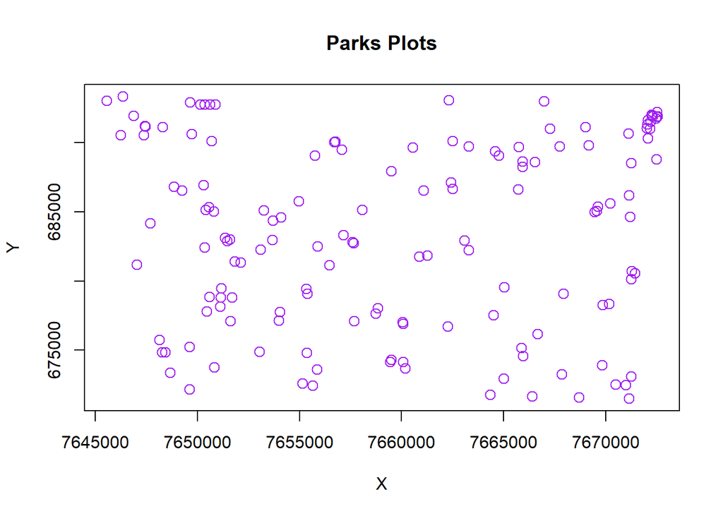

```r
# Read in the sf package
require(sf)

# Read in the parks
parks <- st_read("D:\\MURP\\Winter 2023\\GEOG597_Advanced Quantitative Analy_R\\Lab 1\\parks.shp", quiet = T)

park_points <- st_coordinates(parks)

plot(park_points,col='purple',cex=1.3,axes=T,xlab="X",ylab="Y",main="Parks Plots")
```

```r
dist <- st_distance(parks,parks) %>%
    units::drop_units() # Makes it easier to work with!
```

```r
# Convert instances of points being 0m from themselves to NA - this will ignore them when searching for their nearest neighbor
dist[dist == 0] <- NA

# This will loop through each row of the distance matrix `dist` and find the distance to the nearest neighbor
NND <- apply(X = dist,     # Loop through the `dist` matrix
             MARGIN = 1,   # Loop by rows; in a distance matrix, it doesn't matter which you chose
             min,          # For each row, return the minimum value
             na.rm = TRUE) # Additional argument passed to `min` to ignore NA values

# Now we have the Average Nearest Neighbor distance:
mean(NND)
```

```
## [1] 806.8574
```

```r
## Read in the InnerEast shapefile:
inner_east <- st_read("D:\\MURP\\Winter 2023\\GEOG597_Advanced Quantitative Analy_R\\Lab 1\\innereast.shp")
# Calculate the area (byid defaults to `FALSE`, but I want to point out that this will give us total area. If we set it to TRUE
# we would get a vector for the area of each polygon!)
inner_east_area <- st_area(inner_east, byid = FALSE)

# Solve for density:
park_density <- nrow(parks)/inner_east_area
park_density
```

```
## 2.555424e-07 [1/ft^2]
```

```r
parks_z <- 1.913 * (0.8157 - 1) * sqrt(nrow(parks))
parks_z
```

```
## [1] -4.245456
```

*z-score*: -4.245456

*Conclusion*: We have to reject the Null Hypothesis ($H_0$) as Z < -1.96 and the z-score indicates that pattern of the parks is clustered.

## Elementary Schools

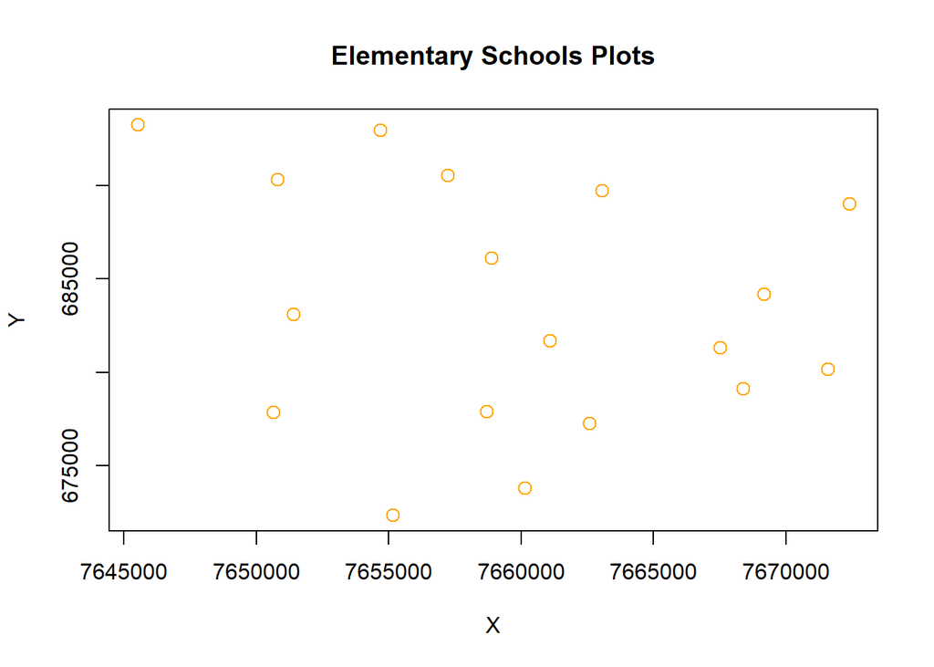

```r
# Read in the sf package
require(sf)

# Read in the elementary schools
elemschs <- st_read("D:\\MURP\\Winter 2023\\GEOG597_Advanced Quantitative Analy_R\\Lab 1\\elemsch.shp", quiet = T)

elemschs_points <- st_coordinates(elemschs)

plot(elemschs_points,col='orange',cex=1.3,axes=T,xlab="X",ylab="Y",main="Elementary Schools Plots")
```

```r
dist <- st_distance(elemschs,elemschs) %>%
    units::drop_units() # Makes it easier to work with!
```

```r
# Convert instances of points being 0m from themselves to NA - this will ignore them when searching for their nearest neighbor
dist[dist == 0] <- NA

# This will loop through each row of the distance matrix `dist` and find the distance to the nearest neighbor
NND <- apply(X = dist,     # Loop through the `dist` matrix
             MARGIN = 1,   # Loop by rows; in a distance matrix, it doesn't matter which you chose
             min,          # For each row, return the minimum value
             na.rm = TRUE) # Additional argument passed to `min` to ignore NA values

# Now we have the Average Nearest Neighbor distance:
mean(NND)
```

```
## [1] 4315.829
```

```r
## Read in the InnerEast shapefile:
inner_east <- st_read("D:\\MURP\\Winter 2023\\GEOG597_Advanced Quantitative Analy_R\\Lab 1\\innereast.shp")
# Calculate the area (byid defaults to `FALSE`, but I want to point out that this will give us total area. If we set it to TRUE
# we would get a vector for the area of each polygon!)
inner_east_area <- st_area(inner_east, byid = FALSE)

# Solve for density:
elemsch_density <- nrow(elemschs)/inner_east_area
elemsch_density
```

```
## 3.17225e-08 [1/ft^2]
```

```r
elemschs_z <- 1.913 * (0.8157 - 1) * sqrt(nrow(elemschs))
elemschs_z
```

```
## [1] -1.49581
```

## Fire Stations

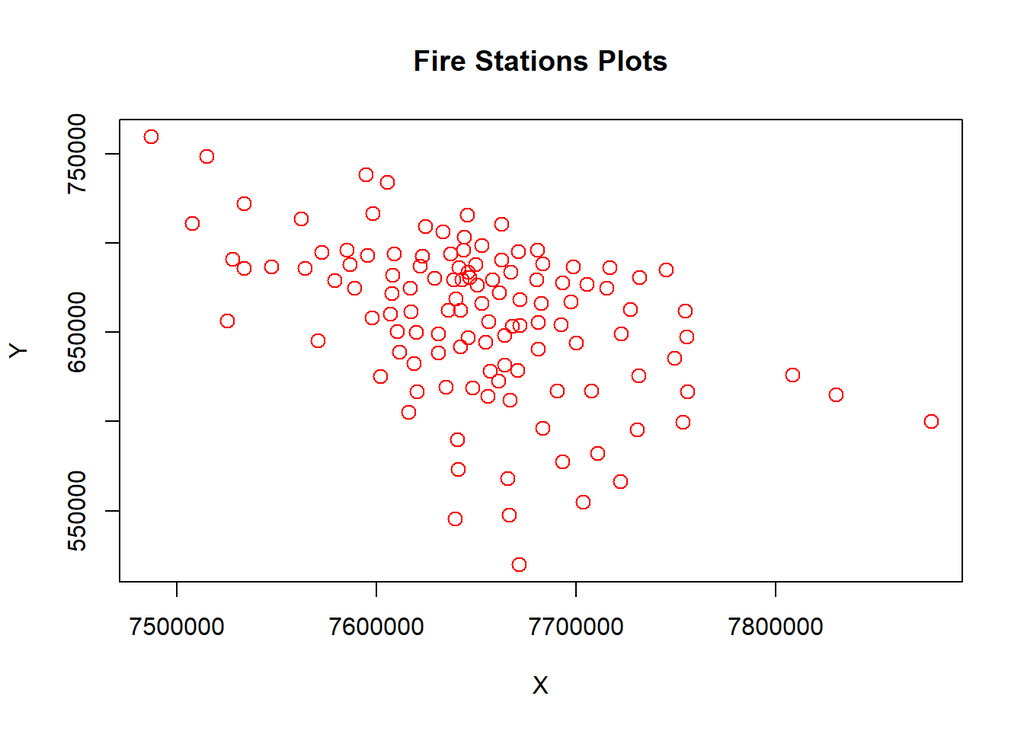

```r
# Read in the sf package
require(sf)

# Read in the elementary schools
fire_sta <- st_read("D:\\MURP\\Winter 2023\\GEOG597_Advanced Quantitative Analy_R\\Lab 1\\fire_sta.shp", quiet = T)

fire_sta_points <- st_coordinates(fire_sta)

plot(fire_sta_points,col='red',cex=1.3,axes=T,xlab="X",ylab="Y",main="Fire Stations Plots")
```

```r
dist <- st_distance(fire_sta,fire_sta) %>%
    units::drop_units() # Makes it easier to work with!
```

```r
# Convert instances of points being 0m from themselves to NA - this will ignore them when searching for their nearest neighbor
dist[dist == 0] <- NA

# This will loop through each row of the distance matrix `dist` and find the distance to the nearest neighbor
NND <- apply(X = dist,     # Loop through the `dist` matrix
             MARGIN = 1,   # Loop by rows; in a distance matrix, it doesn't matter which you chose
             min,          # For each row, return the minimum value
             na.rm = TRUE) # Additional argument passed to `min` to ignore NA values

# Now we have the Average Nearest Neighbor distance:
mean(NND)
```

```
## [1] 12748.77
```

```r
## Read in the InnerEast shapefile:
inner_east <- st_read("D:\\MURP\\Winter 2023\\GEOG597_Advanced Quantitative Analy_R\\Lab 1\\innereast.shp")
# Calculate the area (byid defaults to `FALSE`, but I want to point out that this will give us total area. If we set it to TRUE
# we would get a vector for the area of each polygon!
inner_east_area <- st_area(inner_east, byid = FALSE)

# Solve for density:
fire_sta_density <- nrow(fire_sta)/inner_east_area
fire_sta_density
```

```
## 2.114834e-07 [1/ft^2]
```

```r
fire_sta_z <- 1.913 * (0.8157 - 1) * sqrt(nrow(fire_sta))
fire_sta_z
```

```
## [1] -3.862166
```

# **Ripley’s K Function**

```r
require(spatstat)
```

## Defining a new boundary

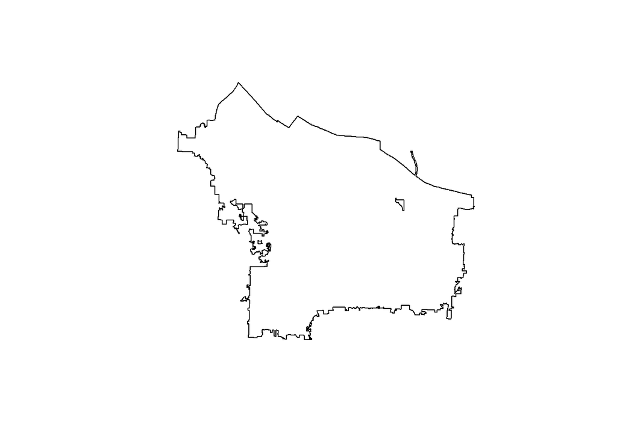

```r
portland <- cities[cities$CITYNAME == 'Portland',]
plot(st_geometry(portland)) # Just plot the geometry
```

## Light Rail Stops

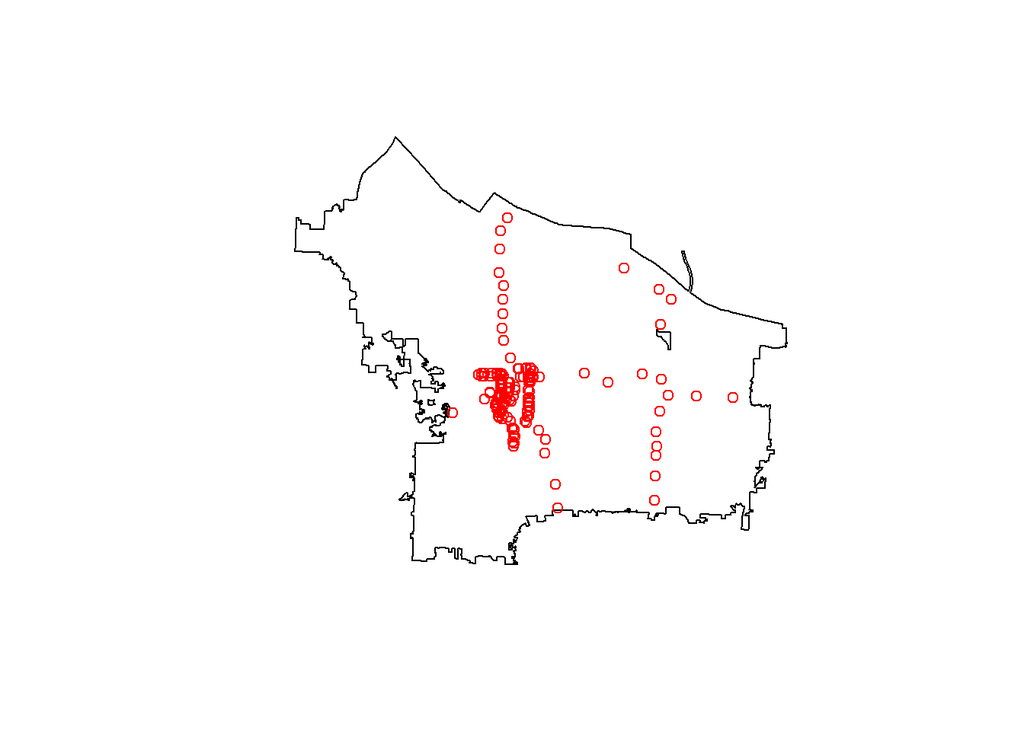

```r
lrt_stop_ppp <- as.ppp(lrt_stop) # Convert the points to a ppp object
lrt_stop_ppp$window <- as.owin(portland) # Update the boundary to that of of the Portland outline
```

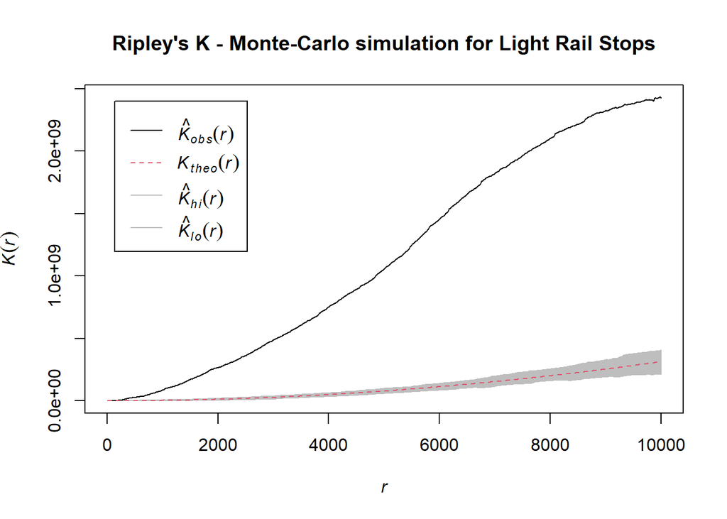

```r
k_ls <- envelope(Y = lrt_stop_ppp,
fun = Kest,
nsim = 99,
funargs = list(correction = 'border', rmax = 10000),
verbose = F)

plot(k_ls, main = "Ripley's K - Monte-Carlo simulation for Light Rail Stops")
```

*Conclusion*: In Ripley’s K-Monte-Carlo simulation, where the line is above the confidence interval window it means clustering, where the line is below the confidence interval window it means dispersed, and finally where the line is within the confidence interval window it fails to reject the Null hypothesis. Because this line is above the confidence interval window, there is significant clustering in the data.

## Schools

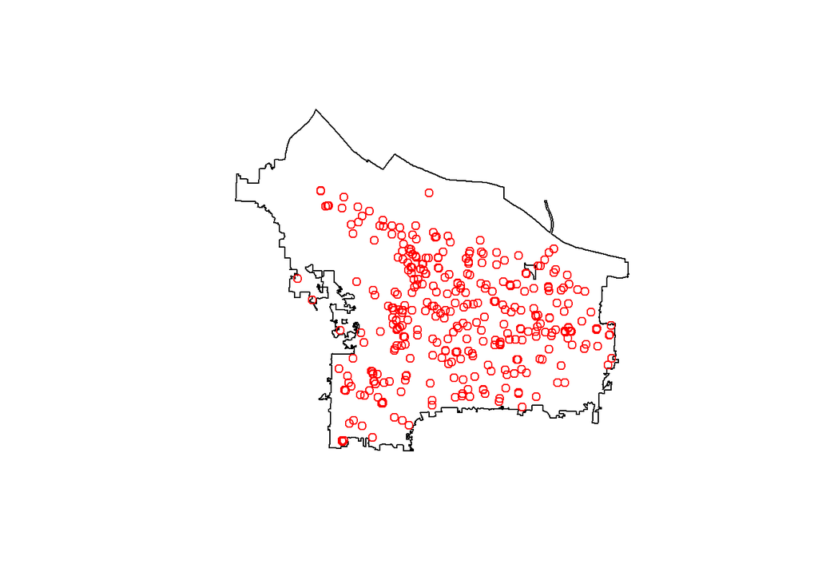

```r
sch_ppp <- as.ppp(schools) # Convert the points to a ppp object
sch_ppp$window <- as.owin(portland) # Update the boundary to that of of the Portland outline
```

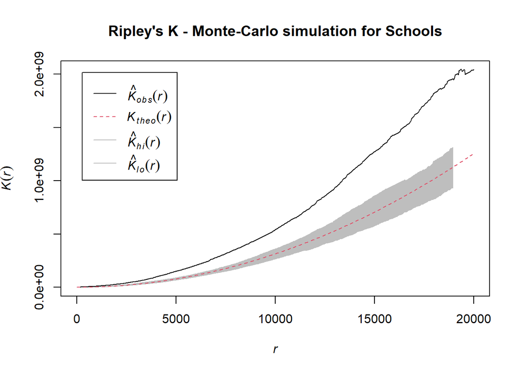

```r
k_sch <- envelope(Y = sch_ppp,
fun = Kest,
nsim = 99,
funargs = list(correction = 'border', rmax = 20000),
verbose = F)

plot(k_sch, main = "Ripley's K - Monte-Carlo simulation for Schools")
```

*Conclusion*: Because this line is above the confidence interval window, there is significant clustering in the data.

## Fire Station

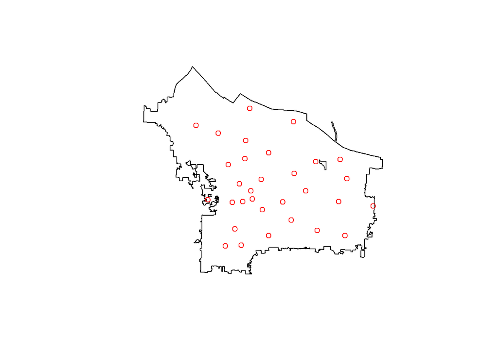

```r
fir_st_ppp <- as.ppp(fir_st) # Convert the points to a ppp object
fir_st_ppp$window <- as.owin(portland) # Update the boundary to that of of the Portland outline
```

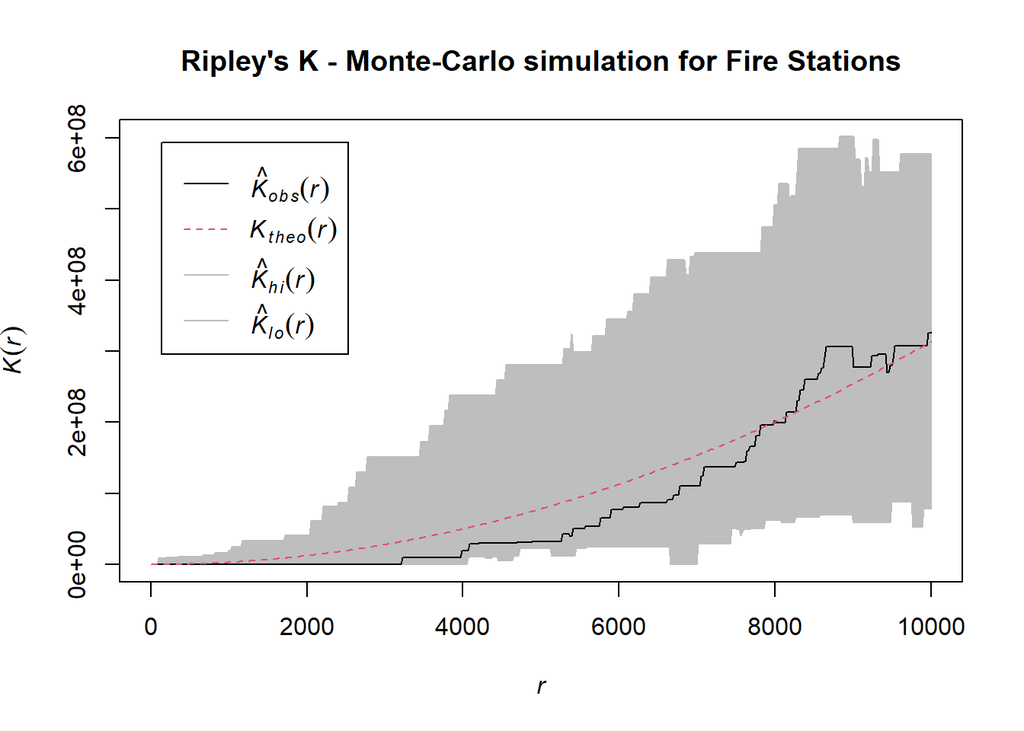

```r
k_fir_st <- envelope(Y = fir_st_ppp,
fun = Kest,
nsim = 99,
funargs = list(correction = 'border', rmax = 10000),
verbose = F)

plot(k_fir_st, main = "Ripley's K - Monte-Carlo simulation for Fire Stations")
```

*Conclusion*: The line is within the confidence index. So it fails to reject the null hypothesis.

## Community Center

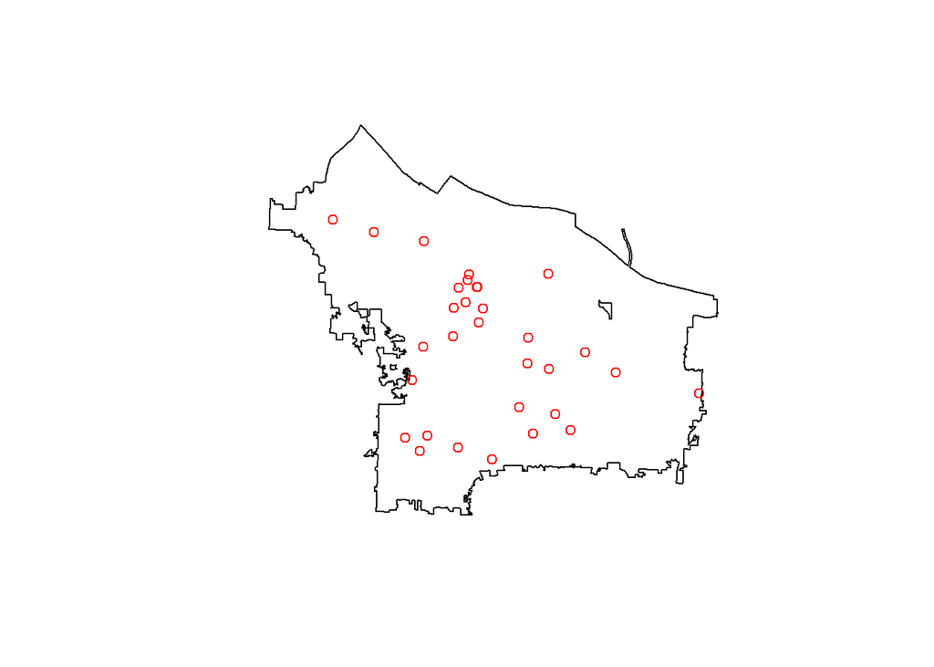

```r
com_ppp <- as.ppp(com) # Convert the points to a ppp object
com_ppp$window <- as.owin(portland) # Update the boundary to that of of the Portland outline
```

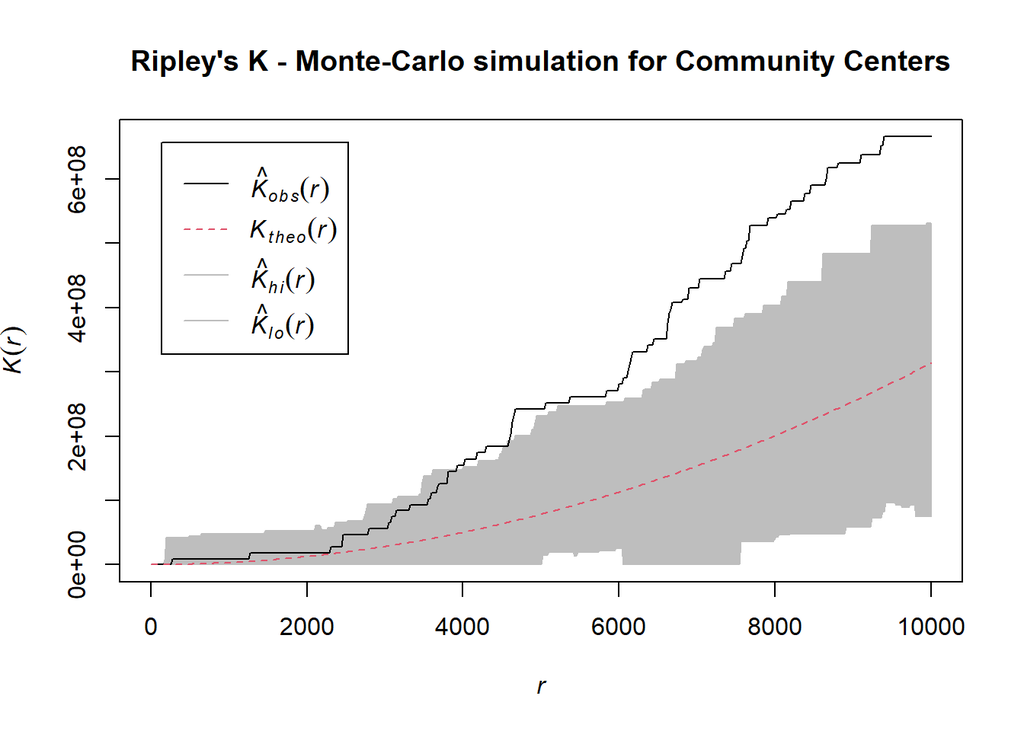

```r
k_com <- envelope(Y = com_ppp,
fun = Kest,
nsim = 99,
funargs = list(correction = 'border', rmax = 10000),
verbose = F)

plot(k_com, main = "Ripley's K - Monte-Carlo simulation for Community Centers")
```

*Conclusion*: Because this line is above the confidence interval window, there is significant clustering in the data.

## Parks

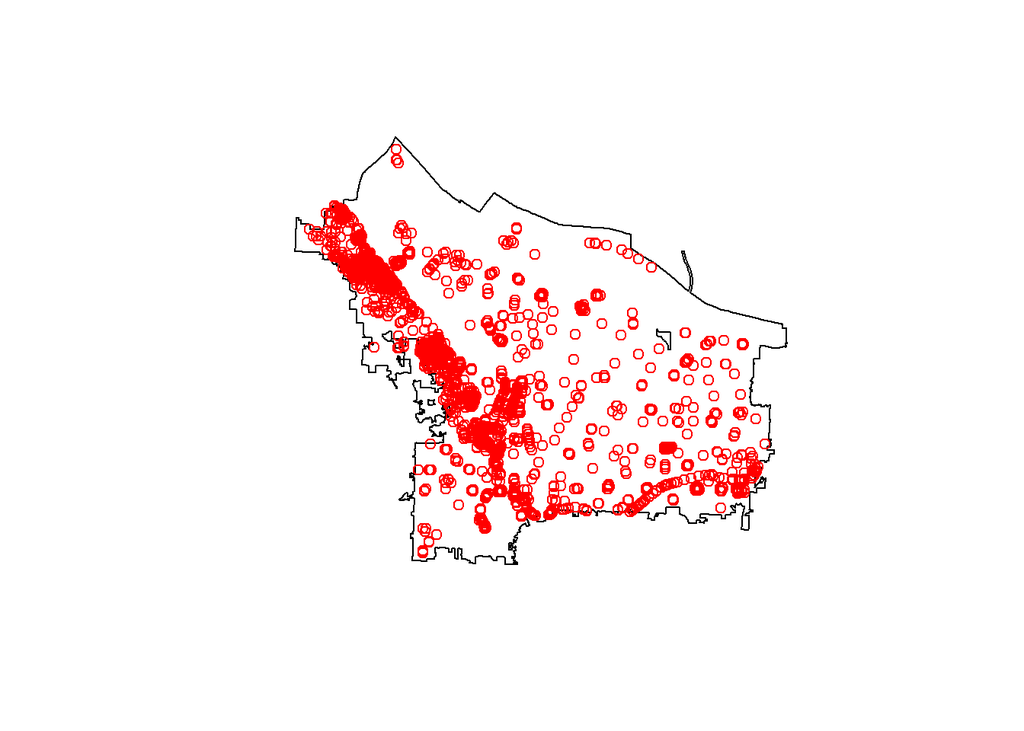

```r
prk_ppp <- as.ppp(prk) # Convert the points to a ppp object
prk_ppp$window <- as.owin(portland) # Update the boundary to that of of the Portland outline
```

```r
k_prk <- envelope(Y = prk_ppp,
fun = Kest,
nsim = 99,
funargs = list(correction = 'border', rmax = 20000),
verbose = F)
```

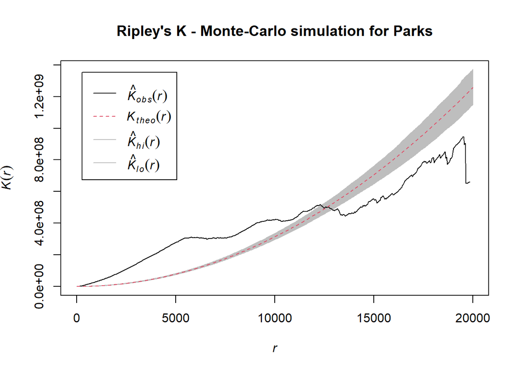

```r
plot(k_prk, main = "Ripley's K - Monte-Carlo simulation for Parks")
```